# Домашнее задание №4. Логистическая регрессия. Оптимизация. Подбор гиперпараметров

## Ф.И.О: Шарипов Артем Сергеевич

По вопросам в задании писать в беседу курса или в лс (tg: @Skorik_S)

## Задание 1: Теоретическая часть

Постановка задачи логистической регрессии: $$ \mathcal{L}(\theta, X, y) = \dfrac{1}{N}\sum_{i=1}^N\log(1 + e^{-y_i\langle\theta, x_i\rangle}) → \min_{θ \in \mathbb{R}^d}, \tag{1} $$

в которой

1. $θ \in \mathbb{R}^d$ - вектор параметров модели.
2. $(x_i, y_i)$ - обучающая пара. В данной постановке $y = \{-1, 1\}$.

### Задача 0 (0.5 балла)

1. *Получите постановку логистической регрессии, используя принцип максимума правдоподобия в предположении $y = \{0, 1\}$.*
2. Проверьте, что если метки классов $y = \{-1, 1\}$, то полученная постановка примет вид (1).

#### Ваше решение:

1. Для пары $(x_i, y_i)$ модель задаёт: $$ \mathbb{P}(y_i = 1 | x_i, \theta) = \sigma(\langle \theta, x_i \rangle),$$ $$ \mathbb{P}(y_i = 0 | x_i, \theta) = 1 - \sigma(\langle \theta, x_i \rangle). $$

Логарифм правдоподобия $$L(\theta) = \frac{1}{n}\sum_{i = 1}^n \log{\mathbb{P}(y_i | x_i, \theta)} \to \max_{\theta}$$ В случае двух классов $y_i \in Y = \{0, 1\}$, можно рассмотреть $\mathbb{P} (y = 1 | x, \theta)$. Тогда формула выше примет вид: $$L (\theta) = \sum_{i = 1}^n y_i \log{\mathbb{P} (y_i = 1 | x_i, \theta)} + (1 - y_i) \log{\left(1 - \mathbb{P}(y_i = 1 | x_i, \theta)\right)} \to \max_{\theta}$$ Остается написать минус перед формулой и получить формулировку на минимизацию, то есть минимизировать следующий функционал ошибки $$\mathcal{L}(\theta) = -\frac{1}{N} \ell(\theta) = -\frac{1}{N}\sum_{i=1}^N \Bigl[ y_i \log \sigma(\langle \theta, x_i \rangle) + (1 - y_i)\log\bigl(1 - \sigma(\langle \theta, x_i \rangle)\bigr) \Bigr].$$

2. Пусть теперь $\hat{y}_i = 2y_i - 1$: $y_i = \frac{1 + \hat{y}_i}{2}$. Заметим, что $$ \log \sigma(z) = -\log(1 + e^{-z}),$$ $$ \log(1 - \sigma(z)) = -\log(1 + e^{z}). $$ Тогда

$$ \mathcal{L}(\theta) = \frac{1}{N}\sum_{i=1}^N \Bigl[ y_i \log(1 + e^{-\langle \theta, x_i \rangle}) + (1 - y_i)\log(1 + e^{\langle \theta, x_i \rangle}) \Bigr] \Longrightarrow$$ $$\Longrightarrow \mathcal{L}(\theta) = \frac{1}{N}\sum_{i=1}^N \log\bigl(1 + e^{-\hat{y_i} \langle \theta, x_i \rangle}\bigr).$$

Так как при переходе к обозначению $y_i \in \{-1, 1\}$ мы можем опустить шапочку над y, окончательная постановка логистической регрессии принимает вид:

$$\mathcal{L}(\theta, X, y) = \dfrac{1}{N}\sum_{i=1}^N\log(1 + e^{-y_i\langle\theta, x_i\rangle}) → \min_{θ \in \mathbb{R}^d},\text{ Ч.т.д.}$$

### Задача 1* (2 балла)

1. Покажите, что градиент функции потерь равен:

$$\nabla \mathcal{L}(\theta, X, y) = - \dfrac{1}{N}\sum_{i=1}^N \dfrac{y_i x_{i}e^{-y_i\langle\theta, x_i\rangle}}{1 + e^{-y_i\langle\theta, x_i\rangle}}. $$

2. Покажите, что гессиан функции потерь равен:

$$ \nabla^2 \mathcal{L}(\theta, X, y) = \dfrac{1}{N}X^\top D X, \tag{2}$$ где $D$ - диагональная матрица с элементами $\sigma(-y_i\langle\theta, x_i\rangle)(1 - \sigma(-y_i\langle\theta, x_i\rangle))$, где $\sigma(\cdot)$ - функция сигмоиды.

#### Ваше решение:*

1. Положим для удобства $z_i = y_i\langle\theta,x_i\rangle$. Тогда

$$ \mathcal{L}(\theta,X,y)=\frac{1}{N}\sum_{i=1}^N \log\bigl(1+e^{-z_i}\bigr). $$

Вычислим градиент по $\theta$ для одного слагаемого:

$$ \frac{\partial}{\partial\theta}\log\bigl(1+e^{-z_i}\bigr) = \frac{1}{1+e^{-z_i}}\cdot\frac{\partial}{\partial\theta}(e^{-z_i}) = \frac{1}{1+e^{-z_i}}\cdot e^{-z_i}\cdot\frac{\partial(-z_i)}{\partial\theta}. $$ Так как $z_i=y_i\langle\theta,x_i\rangle$, имеем $\partial z_i/\partial\theta = y_i x_i$, поэтому очевидно $$ \frac{\partial(-z_i)}{\partial\theta} = -y_i x_i. $$ Подставив, получим $$ \frac{\partial}{\partial\theta}\log\bigl(1+e^{-z_i}\bigr) = \frac{e^{-z_i}}{1+e^{-z_i}}\cdot(-y_i x_i) = -\,\frac{y_i x_i\,e^{-y_i\langle\theta,x_i\rangle}}{1+e^{-y_i\langle\theta,x_i\rangle}}. $$

Просуммировав по $i$ и домножив на $1/N$, получаем градиент полной функции потерь:

$$ \nabla\mathcal{L}(\theta,X,y) = -\frac{1}{N}\sum_{i=1}^N \frac{y_i x_i\,e^{-y_i\langle\theta,x_i\rangle}}{1+e^{-y_i\langle\theta,x_i\rangle}},\text{ Ч.т.д.} $$

2. Из предыдущего пункта имеем $$ \nabla\mathcal{L}(\theta) = -\frac{1}{N}\sum_{i=1}^N y_i x_i;\sigma\bigl(-y_i\langle\theta,x_i\rangle\bigr), $$ где использовано, что $\dfrac{e^{-z}}{1+e^{-z}}=\sigma(-z).$

Найдём производную вектор-функции по $\theta$. Для $i$-го слагаемого $ g_i(\theta) := -\frac{1}{N}y_i x_i;\sigma\bigl(-y_i\langle\theta,x_i\rangle\bigr). $

$ \frac{\partial}{\partial\theta}\sigma\bigl(-y_i\langle\theta,x_i\rangle\bigr) = \sigma'\bigl(-y_i\langle\theta,x_i\rangle\bigr)\cdot\frac{\partial(-y_i\langle\theta,x_i\rangle)}{\partial\theta} = \sigma'\bigl(-y_i\langle\theta,x_i\rangle\bigr)\cdot(-y_i x_i). $

Поэтому матрица Гессе для $g_i$ равна $ \nabla^2 g_i(\theta) = -\frac{1}{N}y_i, x_i\bigl(\sigma'\bigl(-y_i\langle\theta,x_i\rangle\bigr)\cdot(-y_i x_i)^\top\bigr) = \frac{1}{N}\sigma'\bigl(-y_i\langle\theta,x_i\rangle\bigr); x_i x_i^\top. $

Суммируя по $i$ получаем гессиан полной функции потерь: $$ \nabla^2\mathcal{L}(\theta) = \sum_{i=1}^N \nabla^2 g_i(\theta) = \frac{1}{N}\sum_{i=1}^N \sigma'\bigl(-y_i\langle\theta,x_i\rangle\bigr) x_i x_i^\top. $$

Отметим, что производная сигмоиды равна $$ \sigma'(z)=\sigma(z)\bigl(1-\sigma(z)\bigr). $$ Пусть $D \in \mathbb{R}^{N\times N}$ — диагональная матрица, у которой на диагонали $$ D_{ii}=\sigma\bigl(-y_i\langle\theta,x_i\rangle\bigr)\Bigl(1-\sigma\bigl(-y_i\langle\theta,x_i\rangle\bigr)\Bigr). $$ Тогда сумма матриц $\displaystyle \sum_i \sigma'(\cdot), x_i x_i^\top$ представляется как $$ \sum_{i=1}^N \sigma'(\cdot) x_i x_i^\top = X^\top D X. $$

Итак, $$ \nabla^2 \mathcal{L}(\theta, X, y) = \dfrac{1}{N}X^\top D X, \tag{2}$$ где $D$ - диагональная матрица с элементами $\sigma(-y_i\langle\theta, x_i\rangle)(1 - \sigma(-y_i\langle\theta, x_i\rangle))$, где $\sigma(\cdot)$ - функция сигмоиды, Ч.т.д.

### Задача 2* (1 балл)

1. Покажите что в выражении (2) $\nabla^2\mathcal{L} \succeq 0$. Что это говорит об $\mathcal{L}$ и её экстремумах?
2. В каких случаях в выражении (2) $\nabla^2\mathcal{L} \succ 0$? Что в этом случае мы можем сказать о глобальном минимуме? Всегда ли он существует? Ответ обоснуйте.

#### Ваше решение:*

Регуляризируем исходную задачу: $$ \mathcal{L}(\theta, X, y) = -\dfrac{1}{N}\sum_{i=1}^N\log(1 + e^{-y_i\langle\theta, x_i\rangle}) + \dfrac{\lambda}{2}\|\theta\|^2 → \min_{θ \in \mathbb{R}^d}, \tag{3} $$ здесь $\lambda > 0$ - параметр регуляризации. Задача (3) представляет собой *минимизацию эмпирического риска*.

### Задача 3 (2 балла)

1. Покажите, что задача (3) L-гладкая с константой $$L = \dfrac{1}{4N}\lambda_{max}(XX^\top) + \lambda \tag{4}.$$
2. Покажите, что задача (3) $\mu$-сильно-выпуклая с константой $\mu = λ$.

Для доказательства п.1 и п.2 воспользуйтесь тем, что $L = \lambda_{max}(\nabla^2 \mathcal{L}(\theta, X, y))$ и $\mu = \lambda_{min}(\nabla^2 \mathcal{L}(\theta, X, y))$, где $\lambda_{max}(\cdot)$ и $\lambda_{min}(\cdot)$ - максимальное и минимальное собственное значение матрицы.

#### Ваше решение:

1. Воспользуемся результатом задачи выше. $$l_i''(s_i) \leq 1/4,\text{ где } l_i = \log{(1 + e^{-y_i \langle \theta, x_i \rangle})}, \ s_i = \langle \theta, x_i \rangle.$$ Тогда из неравенства получаем $$\frac{1}{N}X^TDX \preceq \frac{1}{4N} X^T X + \lambda E,\text{ где D – матрица в смысле задачи выше.}$$ Применяя монотонность максимального собственного значения для сумм положительно полуопределенных матриц, $$\lambda_{max}(\nabla^2 \mathcal{L}(\theta, X, y)) \leq \lambda_{max}\left(\frac{1}{4N} X^T X\right) + \lambda = \frac{1}{4N} \lambda_{max}\left(X^T X\right) + \lambda.$$ Остается воспользоваться данным в условии и получить $L = \frac{1}{4N} \lambda_{max}\left(X^T X\right) + \lambda$, Ч.т.д.
2. Аналогично для $\mu$-сильно-выпуклости $$\nabla^2\mathcal{L}(\theta) \succeq \lambda E,\text{ в задаче $2^*$ было было показать такое для 0, но там не было регуляризации.}$$ Откуда минимальное собственное значение удовлетворяет $$\lambda_{min} (\nabla^2 \mathcal{L} (\theta)) \geq \lambda,$$ а значит, с учетом данного в условии, функция $\mathcal{L}$ $\mu$-сильно выпукла с константой $\mu = \lambda$, Ч.т.д.

### Задача 4* (1 балл)

1. Всегда ли существует глобальный минимум задачи (3)? Ответ обоснуйте.

#### Ваше решение:*

## Задание 2: Сравнение алгоритмов оптимизации

Для практической части мы пользуемся библиотекой `numpy`: [документация](https://numpy.org/doc/)

Не пользуйтесь другими библиотеками (`torch`, `jax` и тп)

```python
from typing import Callable
import time
from functools import partial
from tqdm import tqdm
from sklearn.datasets import load_svmlight_file
from sklearn.model_selection import train_test_split
import numpy as np
import matplotlib.pyplot as plt
import requests
```

Подготовим данные

```python
url = 'https://drive.google.com/uc?id=1vcd064Gz1Apf9Tz-VkSSkchwPZopBh98'
filename = 'mushrooms.txt'

response = requests.get(url)
with open(filename, 'wb') as file:
    file.write(response.content)
```

```python
data = load_svmlight_file(filename)
mushrooms_x, mushrooms_y = data[0].toarray(), data[1]
# сделаем y -1 или 1
mushrooms_y = 2 * mushrooms_y - 3
```

Разделим данные на train/test

**Важно:** не меняйте код ниже. random_state зафиксирован для воспроизводимости.

```python
train_mush_x, test_mush_x, train_mush_y, test_mush_y = train_test_split(
    mushrooms_x, mushrooms_y, test_size=0.2, random_state=42
)

print(f"{train_mush_x.shape=}")
print(f"{train_mush_y.shape=}")
```

```
train_mush_x.shape=(6499, 112)
train_mush_y.shape=(6499,)
```

### Задача 0 (1 балл)

Найдите константу гладкости $L$ согласно (4) на практике для `train_mush_x`.

```python
def get_lipschitz(x_values: np.ndarray) -> float:
    N = x_values.shape[0]
    XXt = x_values @ x_values.T
    eigvals = np.linalg.eigvals(XXt)
    lambda_max = np.real(eigvals).max()
    L = (1 / (4 * N)) * lambda_max
    L += (L / 1000)
    return L
```

```python
def assert_lipschitz(get_lipschitz: Callable) -> None:
    true_lipschitz = 2.5872260889612666
    your_lipschitz = get_lipschitz(train_mush_x)
    assert np.allclose(true_lipschitz, your_lipschitz, atol=1e-6), "Failed on get_lipschitz(train_mush_x)"
    print("Success!!!")

assert_lipschitz(get_lipschitz)
```

```
Success!!!
```

```python
lipschitz_mush = get_lipschitz(train_mush_x)
lambda_mush = lipschitz_mush / 1000
```

### Задача 1 (2 балла)

Реализуйте подсчёт значения, градиента и гессиана целевой функции (3).

```python
def mush_exp(x: np.ndarray, y: np.ndarray, w: np.ndarray) -> float:
    # TODO: Calculate exp(-y * <w,x>)
    exp = np.exp(-np.dot(y, np.dot(w, x)))
    return exp


def mush_f(
    w: np.ndarray, x: np.ndarray = train_mush_x, y: np.ndarray = train_mush_y
) -> float:
    # TODO: Calculate loss function
    N = x.shape[0]
    Loss = 0
    for i in range(N):
      Loss += np.log(1 + mush_exp(x[i], y[i], w))
    Loss /= N
    Loss += (lambda_mush * np.dot(w, w) / 2 )
    return Loss


def mush_grad(
    w: np.ndarray, x: np.ndarray = train_mush_x, y: np.ndarray = train_mush_y
) -> np.ndarray:
    # TODO: Calculate gradient of loss function
    grad_val = 0
    N = x.shape[0]
    for i in range(N):
      grad_val += (y[i] * x[i] * mush_exp(x[i], y[i], w)) / (1 + mush_exp(x[i], y[i], w))
    grad_val /= (-N)
    grad_val += (lambda_mush * w)
    return grad_val

def mush_exp_sig(x: np.ndarray, y: np.ndarray, w: np.ndarray) -> float:
    # TODO: Calculate exp(-y * <w,x>)
    exp = np.exp(np.dot(y, np.dot(w, x)))
    return exp

def mush_hess(
    w: np.ndarray, x: np.ndarray = train_mush_x, y: np.ndarray = train_mush_y
) -> np.ndarray:
    N = x.shape[0]
    D = np.zeros((N, N))
    for i in range(N):
      exp_val = mush_exp_sig(x[i], y[i], w)
      sigmoid_val = 1 / (1 + exp_val)
      D[i][i] = sigmoid_val * (1 - sigmoid_val)
    hess = np.dot(x.T, np.dot(D, x))
    hess /= N
    hess += lambda_mush * np.eye(x.shape[1])
    return hess


def mush_accuracy(
    w: np.ndarray, x: np.ndarray = test_mush_x, y: np.ndarray = test_mush_y
) -> float:
    if len(x) == 0:
        return 0
    return np.mean((np.sign(x @ w) == y))
```

```python
def assert_mush(mush_f: Callable, mush_grad: Callable, mush_hess: Callable):
    w = np.zeros(train_mush_x[0].shape[0])
    assert np.allclose(mush_f(w), 0.6931471805599453, atol=1e-6), "Failed on mush_f(w) for w=0"
    assert np.allclose(mush_grad(w).sum(), -0.3732112632712724, atol=1e-6), "Failed on mush_grad(w) for w=0"
    assert np.allclose(mush_hess(w).sum(), 110.53976932196366, atol=1e-6), "Failed on mush_hess(w) for w=0"

    w = np.ones(train_mush_x[0].shape[0])
    assert np.allclose(mush_f(w), 10.271673398468815, atol=1e-6), "Failed on mush_f(w) for w=1"
    assert np.allclose(mush_grad(w).sum(), 10.416558042769106, atol=1e-6), "Failed on mush_grad(w) for w=1"
    assert np.allclose(mush_hess(w).sum(), 0.2897696563545762, atol=1e-6), "Failed on mush_hess(w) for w=1"
    print("Success!!!")

assert_mush(mush_f, mush_grad, mush_hess)
```

```
Success!!!
```

### Задача 2 (2 балла)

Рассмотрим и реализуем метод градиентного спуска (Gradient Descent)

$$ \begin{equation*} w_{k+1} = w_k - \gamma_k \nabla \mathcal{L}(w_k) \end{equation*} $$

```python
# Фиксируем рандомизацию для воспроизводимости
seed = 42
np.random.seed(seed)
start_w_mush = np.random.randn(train_mush_x.shape[1])
```

```python
# Базовый класс оптимизатора
class ManualSolver:
    def __init__(
        self,
        lr: float | Callable, # Скорость обучения
        name: str, # Название оптимизатора (для логгирования)
        first_order: bool, # Использует ли оптимизатор grad_f
        second_order: bool, # Использует ли оптимизатор hess_f
    ) -> None:
        super().__init__()
        self.name = name
        self.lr = lr if isinstance(lr, Callable) else lambda _: lr
        self.first_order = first_order
        self.second_order = second_order

    def step(self, w: np.ndarray, k: int, grad_f: np.ndarray, hess_f: np.ndarray) -> np.ndarray:
        # эту функцию должны переопределить наследуемые классы
        raise NotImplementedError
```

#### Задача 2.1

Реализуйте шаг обучения и тестирования.

**Важно:** критерием сходимости является отношение $\frac{\| \nabla f(w^k) \|}{\| \nabla f(w^0) \|}$ на **обучающей** выборке. В связи с этим, подсчет `grad_norm`$=\| \nabla f(w^k) \|$ необходимо производить на обучающей выборке `train_mush_x`.

Подсчет точности и лосса в `eval_optimizer_step` проводятся на тестовой выборке.

```python
def train_optimizer_step(
    optimizer: ManualSolver,
    w: np.ndarray,
    iter_num: int,
    x: np.ndarray = train_mush_x,
    y: np.ndarray = train_mush_y
) -> np.ndarray:
    # TODO: implement train_step pipeline;
    # OUTPUT: Updated training weights
    grad_f = mush_grad(w, x, y) if optimizer.first_order else None
    hess_f = mush_hess(w, x, y) if optimizer.second_order else None

    updated_w = optimizer.step(w, iter_num, grad_f, hess_f)

    return updated_w
```

```python
def eval_optimizer_step(
    w: np.ndarray,
    x: np.ndarray = test_mush_x,
    y: np.ndarray = test_mush_y
) -> list[float, float, float]:
    # TODO: implement eval pipeline;
    # OUTPUT: [grad_norm, accuracy, val_loss]
    # You need to calculate `grad_norm` on train_mush_x!!
    _train_x = train_mush_x
    _train_y = train_mush_y
    grad_on_train = mush_grad(w, _train_x, _train_y)
    grad_norm = float(np.linalg.norm(grad_on_train))

    accuracy = float(mush_accuracy(w, x, y))
    val_loss = float(mush_f(w, x, y))

    return [grad_norm, accuracy, val_loss]
```

```python
def test_optimizer(
    optimizer: ManualSolver,
    max_iters: int = 1000,
    start_w: np.ndarray = start_w_mush,
    stop_criterion: float = 1e-8,
) -> dict:

    accuracies = []
    losses = []
    criterion_logs = []  # нормы градиента или что-то другое
    time_logs = []

    w = start_w.copy()

    # initial eval
    start_grad_norm, accuracy, val_loss = eval_optimizer_step(w)
    time_logs.append(0)
    criterion_logs.append(start_grad_norm / start_grad_norm)
    accuracies.append(accuracy)
    losses.append(val_loss)

    start_time = time.time()

    with tqdm(range(max_iters), desc=optimizer.name) as loop:
        for k in loop:
            # train
            w = train_optimizer_step(optimizer, w, k)
            # eval
            grad_norm, accuracy, val_loss = eval_optimizer_step(w)
            criterion_logs.append(grad_norm / start_grad_norm)
            accuracies.append(accuracy)
            losses.append(val_loss)
            time_logs.append(time.time() - start_time)
            loop.set_postfix(
                {"Loss": val_loss, "Accuracy": accuracy, "Grad norm": grad_norm / start_grad_norm}
            )
            # Остановить, если criterion <= stop_criterion
            if grad_norm / start_grad_norm <= stop_criterion:
                break

    results_dict = {
        "name": optimizer.name,
        "num_iters": list(range(len(accuracies))),
        "Time": time_logs,
        "Accuracy": accuracies,
        "Criterion": criterion_logs,
        "Loss": losses,
        "W": w.copy(),
    }

    return results_dict
```

```python
def plot_results(results_dictionaries: list, title: str, metrics_type: list = ['Criterion'], x: str = 'num_iters') -> None:
    valid_metrics = {'Criterion', 'Accuracy', 'Loss'}
    assert all(metric in valid_metrics for metric in metrics_type), \
        f"All metrics should be one of {valid_metrics}, got {metrics_type}"

    assert x in ['num_iters', 'Time'], f"x should be one of ['num_iters', 'Time'], got {x}"

    num_metrics = len(metrics_type)
    if num_metrics == 1:
        width = 10
    else:
        width = 6 * num_metrics
    fig, axs = plt.subplots(1, num_metrics, figsize=(width, 6), sharey=False)
    if num_metrics == 1:
        axs = [axs]

    for idx, metric_type in enumerate(metrics_type):
        ax = axs[idx]
        for results_dict in results_dictionaries:
            if metric_type == 'Criterion':
                ax.set_yscale('log')
            ax.plot(
                results_dict[x],
                results_dict[metric_type],
                label=results_dict["name"],
                linewidth=2
            )
        ylabel = f"log {metric_type}" if metric_type == 'Criterion' else metric_type
        ax.set_xlabel(x, fontsize=14)
        ax.set_ylabel(ylabel, fontsize=14)
        ax.legend(loc='best', fontsize=12)
        ax.grid(True)

    fig.suptitle(title, fontsize=16)
    plt.tight_layout(rect=[0, 0, 1, 0.96])
    plt.show()
```

#### Задача 2.2

- Реализуйте метод градиентного спуска
- Проведите оптимизацию гиперпараметров . Сравнения проиллюстрируйте на графике. Критерием задачи является $\frac{\| \nabla f(w^k) \|}{\| \nabla f(w^0) \|}$. Однако приветствуются также графики точности и функции потерь на тесте:
1. Протестируйте различные $\gamma_k = \gamma = \frac{s}{L}$, где $s \in [0, 3]$, $L$ -- константа липшица в задаче. Рассмотрите не менее 4-х $s$;
2. Протестируйте различные $\gamma_k = \frac{\gamma}{\delta + k}$, где $\gamma, \delta \in [1, 100]$. Рассмотрите не менее 4-х гиперпараметров;
3. Протестируйте различные $\gamma_k = \frac{\gamma}{\delta + \sqrt{k}}$, где $\gamma, \delta \in [1, 100]$. Рассмотрите не менее 4-х гиперпараметров;
4. Выберите лучшие $\gamma^1_k$, $\gamma^2_k$, $\gamma^3_k$ из п. 1-3 соответственно. Сделайте общий график, сравнивающий их. Также добавьте базовый $\gamma_k = \gamma = 10^{-3}$.

```python
class GradientDescent(ManualSolver):
    def __init__(self, lr, name) -> None:
        super().__init__(lr, name, True, False)
    def step(self, w: np.ndarray, k: int, grad_f: np.ndarray, hess_f: None) -> np.ndarray:
        # TODO: init GradientDescent step
        return w - self.lr(k) * grad_f
```

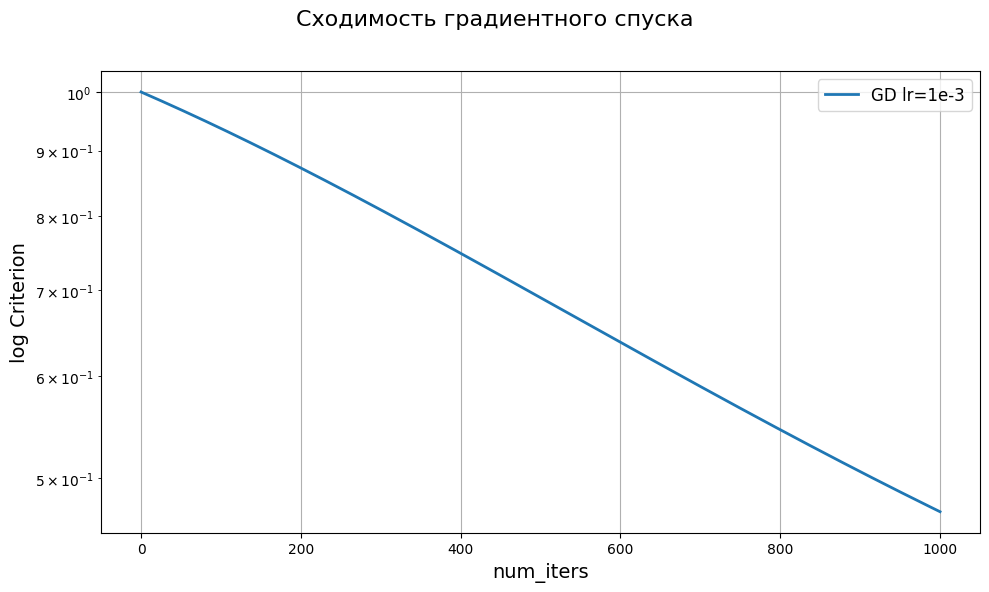

```python
results_total = []

grad_opt = GradientDescent(lr=1e-3, name='GD lr=1e-3')
gd_res_baseline = test_optimizer(grad_opt)
results_total.append(gd_res_baseline)
plot_results([gd_res_baseline], 'Cходимость градиентного спуска')
```

[figure not shown]

```python
results_all_1 = []

s = np.linspace(0.1, 3, 6)
for step in s:
  grad_opt = GradientDescent(lr=(step/lipschitz_mush), name=f'GD s={step}')
  gd_res_baseline = test_optimizer(grad_opt)
  results_all_1.append(gd_res_baseline)
plot_results(results_all_1, 'Сходимость градиентного спуска для всех s')
```

[figure not shown]

```python
results_all = []
gamma = np.linspace(1, 100, 3)
delta = np.linspace(1, 100, 3)

for initial_gamma in gamma:
  for delta_ex in delta:
    def dynamic_lr(k):
      return initial_gamma / (delta_ex + k)
    grad_opt = GradientDescent(lr=dynamic_lr,
                                   name=f'GD g={initial_gamma}, d={delta_ex}')
    gd_res_baseline = test_optimizer(grad_opt)
    results_all.append(gd_res_baseline)

plot_results(results_all, 'Сходимость градиентного спуска для всех комбинаций')
```

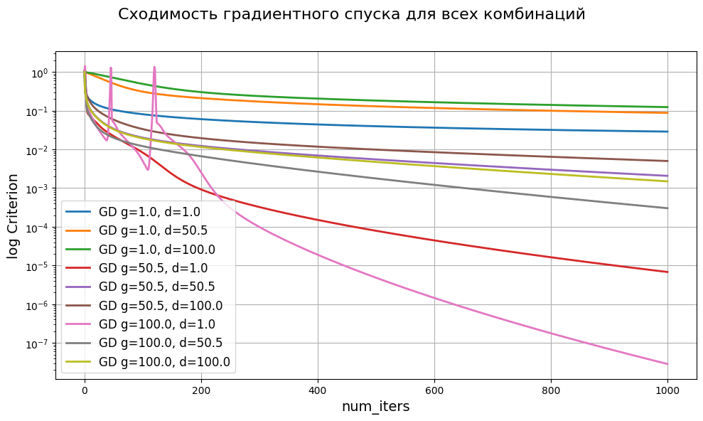

```python
results_all_2 = []
gamma = np.linspace(1, 100, 3)
delta = np.linspace(1, 100, 3)

for initial_gamma in gamma:
  for delta_ex in delta:
    def dynamic_lr(k):
      return initial_gamma / (delta_ex + np.sqrt(k))
    grad_opt = GradientDescent(lr=dynamic_lr,
                                   name=f'GD g={initial_gamma}, d={delta_ex}')
    gd_res_baseline = test_optimizer(grad_opt)
    results_all_2.append(gd_res_baseline)

plot_results(results_all_2, 'Сходимость градиентного спуска для всех комбинаций')
```

[figure not shown]

```python
results_total += results_all_1
results_total += results_all
results_total += results_all_2

plot_results(results_total, 'Сходимость градиентного спуска всех вариантов')
```

```python
min_iters = min(results_total, key=lambda d: d['num_iters'][-1])['num_iters'][-1]

candidates = [
    d for d in results_total
    if abs(d['num_iters'][-1] - min_iters) < 2
]

best_final_gd_res = max(candidates, key=lambda d: d['Accuracy'][-1])
```

### Задача 3 (1 балл)

Рассмотрим метод тяжёлого шарика (Heavy Ball)

$$ w^{k+1} = w^k - \gamma_k \nabla \mathcal{L}(w^k) + \tau_k (w^k - w^{k-1}) $$

- Реализуйте шаг метода тяжёлого шарика
- Используйте шаг $\gamma = \frac{1}{L}$.
1. Рассмотрите моментум $\tau = \frac{\sqrt{L} - \sqrt{\mu}}{\sqrt{L} + \sqrt{\mu}}$ и несколько моментумов в его окрестности: $s \cdot \tau$, где $s \in [0.9, 1.1]$. Рассмотрите не менее 3-х окрестностей.
2. Рассмотрите моментумы равные $\frac{k}{k+3}$, $\frac{k}{k+2}$, $\frac{k}{k+1}$ ($k$ — номер итерации).
3. Сравните полученные результаты.

```python
class HeavyBall(ManualSolver):
    def __init__(self, lr, beta, init_w, name) -> None:
        super().__init__(lr, name, True, False)
        self.beta = beta if isinstance(beta, Callable) else lambda _: beta
        self.w_prev = init_w

    def step(self, w: np.ndarray, k: int, grad_f: np.ndarray, hess_f: None) -> np.ndarray:
        # TODO: implement heavy ball iteration step
        value = w - self.lr(k) * grad_f + self.beta(k) * (w - self.w_prev)
        self.w_prev = w
        return value
```

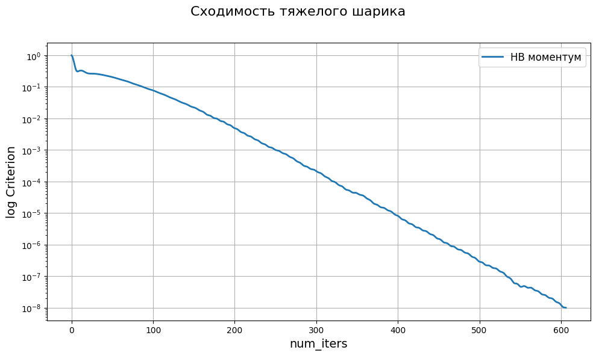

```python
results_total_heavy_ball = []

sqrt_mu = np.sqrt(lipschitz_mush / 1000)
sqrt_lip = np.sqrt(lipschitz_mush)
tau_k = (sqrt_lip - sqrt_mu) / (sqrt_lip + sqrt_mu)
grad_opt = HeavyBall(lr=(1/lipschitz_mush), beta=tau_k, init_w = 0, name='HB моментум')
hb_res_baseline = test_optimizer(grad_opt)
results_total_heavy_ball.append(hb_res_baseline)
plot_results([hb_res_baseline], 'Cходимость тяжелого шарика')
```

Отметим, что при $s = 1.1$ уже на 125 итерации Loss улетел в nan, поэтому в коде ниже мы ограничимся $s = 1.05$ (можно было бы сделать срезку, но я не вижу в этом особого смысла, замечание я уже сделал)

```python
s_list = np.linspace(0.9, 1.05, 5)
sqrt_mu = np.sqrt(lipschitz_mush / 1000)
sqrt_lip = np.sqrt(lipschitz_mush)
tau_k = (sqrt_lip - sqrt_mu) / (sqrt_lip + sqrt_mu)
for s in s_list:
  beta = tau_k * s
  grad_opt = HeavyBall(lr=(1/lipschitz_mush), beta=beta, init_w = 0,
                       name=f'HB при s = {s}')
  hb_res_baseline = test_optimizer(grad_opt)
  results_total_heavy_ball.append(hb_res_baseline)
```

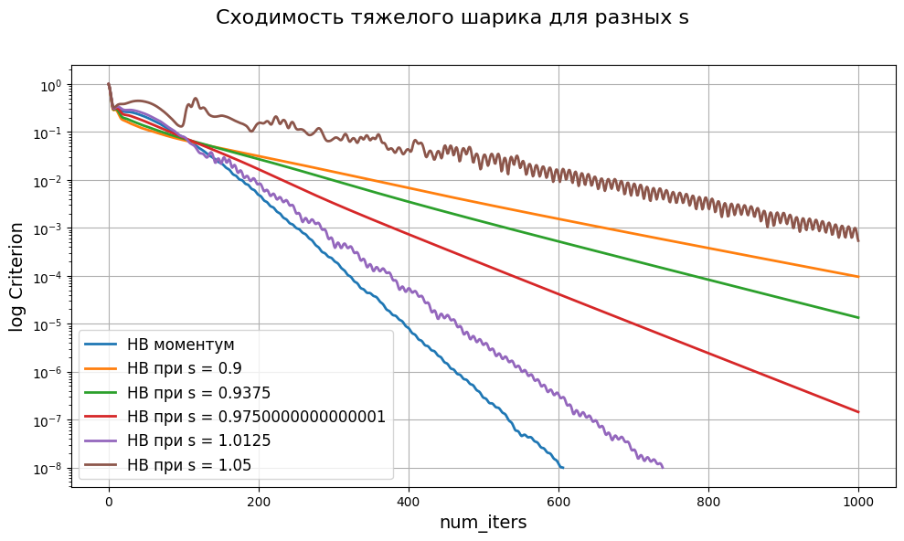

```python
plot_results(results_total_heavy_ball, 'Cходимость тяжелого шарика для разных s')
```

```python
def beta_k_s(n):
    # TODO: return a lambda function that depends on k
    return lambda k: k / (k + n)

results_2_heavy_ball = []

n_list = [3, 2, 1]
for n in n_list:
  grad_opt = HeavyBall(lr=(1/lipschitz_mush), beta=beta_k_s(n), init_w = 0,
                       name=f'HB с n = {n}')
  gd_res_baseline = test_optimizer(grad_opt)
  results_2_heavy_ball.append(gd_res_baseline)
```

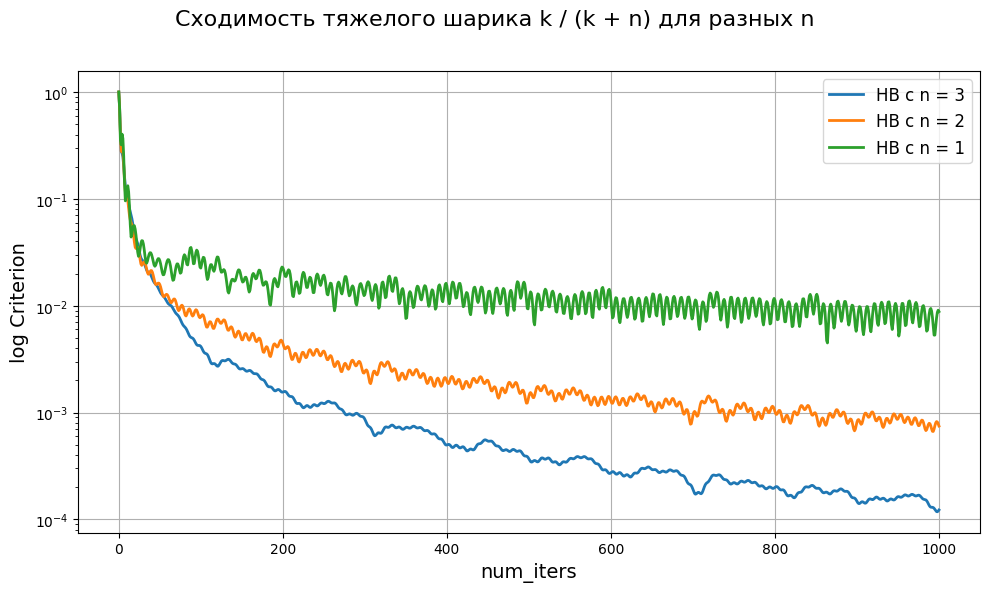

```python
plot_results(results_2_heavy_ball, 'Cходимость тяжелого шарика k / (k + n) для разных n')
```

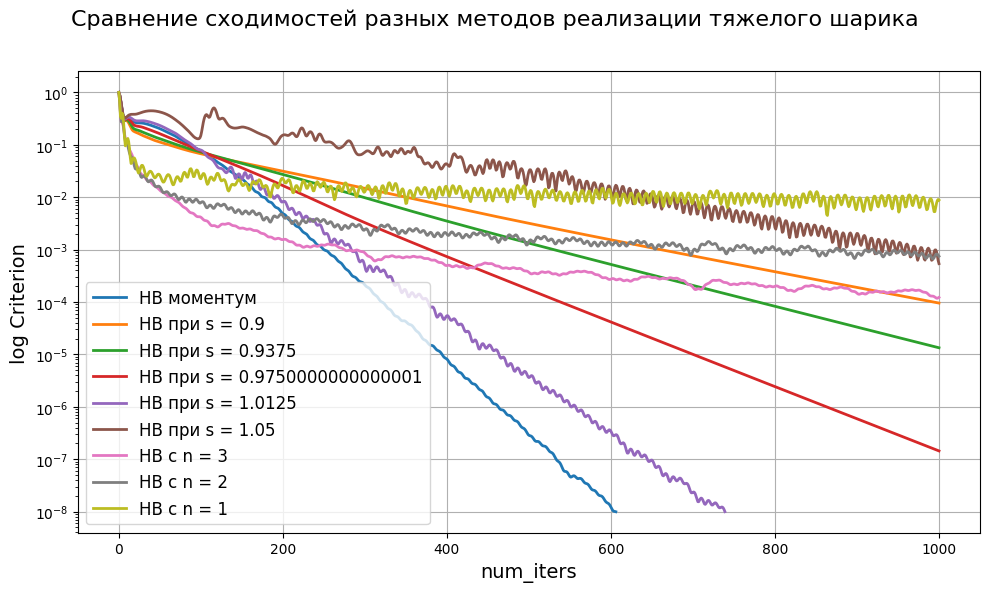

```python
results_total_heavy_ball += results_2_heavy_ball
plot_results(results_total_heavy_ball,
             'Сравнение сходимостей разных методов реализации тяжелого шарика')
```

```python
min_iters = min(results_total_heavy_ball, key=lambda d: d['num_iters'][-1])['num_iters'][-1]

candidates = [
    d for d in results_total_heavy_ball
    if abs(d['num_iters'][-1] - min_iters) < 2
]

best_final_hb_res = max(candidates, key=lambda d: d['Accuracy'][-1])
```

### Задача 4 (2 балла)

Рассмотрим ускоренный градиентный метод (Nesterov Accelerated Gradient)

$$ \begin{align*} & w_{k+1} = y_k - \gamma_k \nabla \mathcal{L}(y_k) \\ & y_{k+1} = w_{k+1} + \tau_k (w_{k+1} - w_k) \end{align*} $$

- Реализуйте шаг ускоренного градиентного метода
- Используйте шаг $\gamma = \frac{1}{L}$.
1. Рассмотрите моментум $\tau = \frac{\sqrt{L} - \sqrt{\mu}}{\sqrt{L} + \sqrt{\mu}}$ и несколько моментумов в его окрестности: $s \cdot \tau$, где $s \in [0.9, 1.1]$. Рассмотрите не менее 3-х окрестностей.
2. Рассмотрите моментумы равные $\frac{k}{k+3}$, $\frac{k}{k+2}$, $\frac{k}{k+1}$ ($k$ — номер итерации).
3. Сравните полученные результаты.

```python
class NAG(ManualSolver):
    def __init__(self, lr, beta, init_w, name) -> None:
        super().__init__(lr, name, False, False)
        self.beta = beta if isinstance(beta, Callable) else lambda _: beta
        self.w_prev = init_w
        self.y_prev = init_w

    def step(self, w: np.ndarray, k: int, grad_f: None, hess_f: None) -> np.ndarray:
        # TODO: implement NAG iteration step
        w = self.y_prev - self.lr(k) * mush_grad(self.y_prev)
        y = w + self.beta(k) * (w - self.w_prev)
        self.w_prev = w
        self.y_prev = y
        return w
```

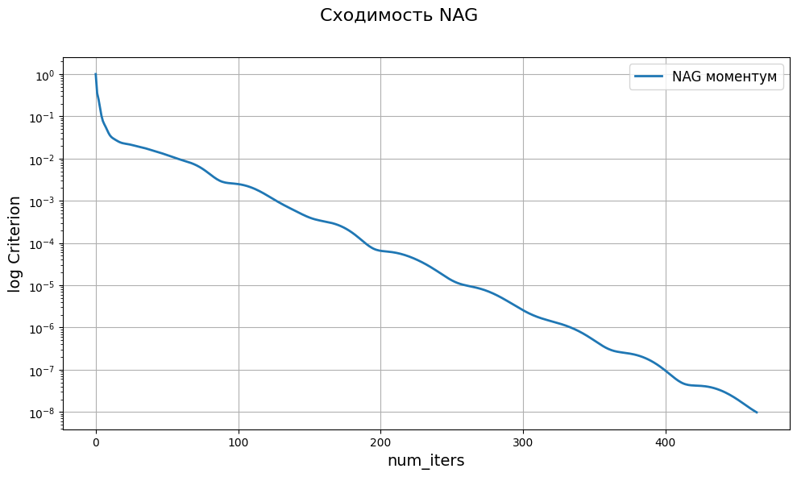

```python
results_total_nag = []

sqrt_mu = np.sqrt(lipschitz_mush / 1000)
sqrt_lip = np.sqrt(lipschitz_mush)
tau_k = (sqrt_lip - sqrt_mu) / (sqrt_lip + sqrt_mu)
grad_opt = NAG(lr=(1/lipschitz_mush), beta=tau_k, init_w = 0, name='NAG моментум')
nag_res_baseline = test_optimizer(grad_opt)
results_total_nag.append(nag_res_baseline)
plot_results([nag_res_baseline], 'Cходимость NAG')
```

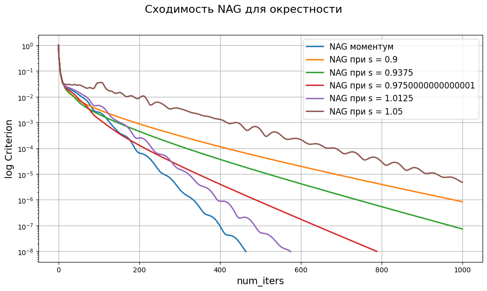

```python
s_list = np.linspace(0.9, 1.05, 5)
sqrt_mu = np.sqrt(lipschitz_mush / 1000)
sqrt_lip = np.sqrt(lipschitz_mush)
tau_k = (sqrt_lip - sqrt_mu) / (sqrt_lip + sqrt_mu)
for s in s_list:
  beta = tau_k * s
  grad_opt = NAG(lr=(1/lipschitz_mush), beta=beta, init_w = 0,
                 name=f'NAG при s = {s}')
  nag_res_baseline = test_optimizer(grad_opt)
  results_total_nag.append(nag_res_baseline)
plot_results(results_total_nag, 'Cходимость NAG для окрестности')
```

```python
def beta_k_s(n):
    # TODO: return a lambda function that depends on k
    return lambda k: k / (k + n)

results_2_nag = []

n_list = [3, 2, 1]
for n in n_list:
  grad_opt = NAG(lr=(1/lipschitz_mush), beta=beta_k_s(n), init_w = 0,
                       name=f'NAG с n = {n}')
  nag_res_baseline = test_optimizer(grad_opt)
  results_2_nag.append(nag_res_baseline)
```

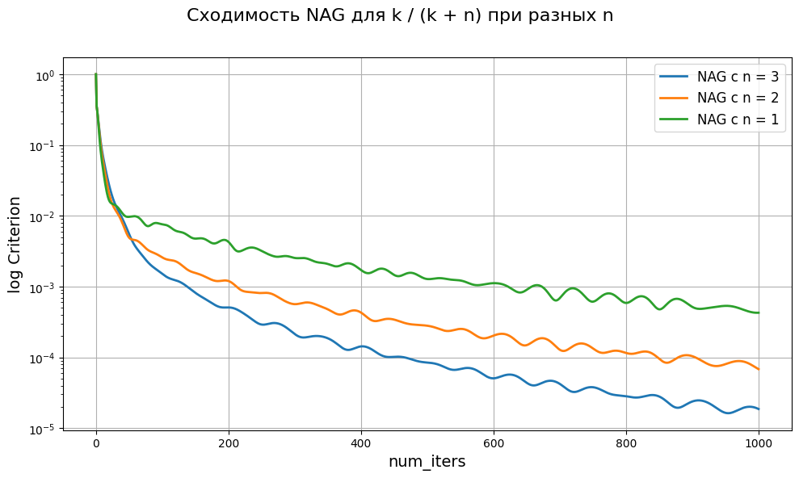

```python
plot_results(results_2_nag, 'Cходимость NAG для k / (k + n) при разных n')
```

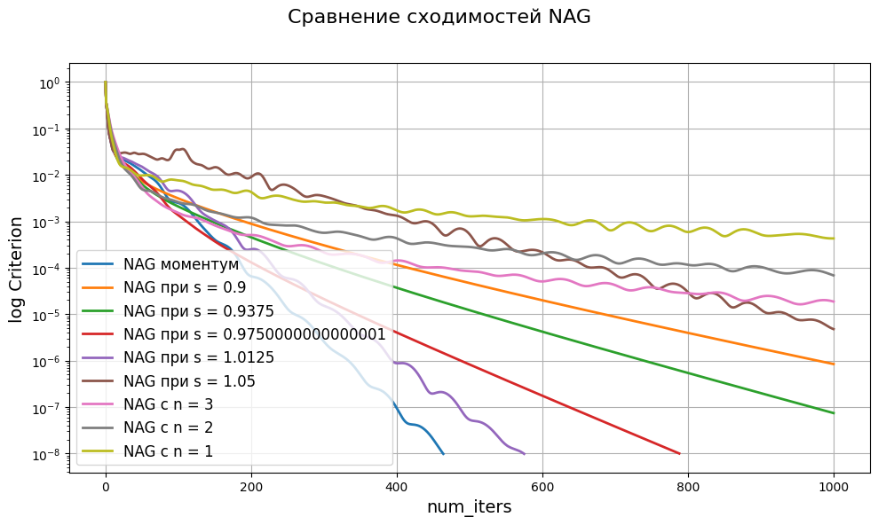

```python
results_total_nag += results_2_nag
plot_results(results_total_nag, 'Сравнение сходимостей NAG')
```

```python
min_iters = min(results_total_nag, key=lambda d: d['num_iters'][-1])['num_iters'][-1]

candidates = [
    d for d in results_total_nag
    if abs(d['num_iters'][-1] - min_iters) < 2
]

best_final_nag_res = max(candidates, key=lambda d: d['Accuracy'][-1])
```

### Задача 5 (1 балла)

Рассмотрим один из самых известных методов второго порядка - Метод Ньютона (Newton's method):

$$ w_{k+1} = w_k - \nabla^2\mathcal{L}(w^k)^{-1} \nabla \mathcal{L}(w^k) $$

А точнее, его модификацию - демпфированный метод Ньютона (Dumped Newton's method):

$$ w_{k+1} = w_k - \gamma_k \nabla^2\mathcal{L}(w^k)^{-1} \nabla \mathcal{L}(w^k) $$

- Реализуйте шаг демпфированного метода Ньютона
1. Протестируйте различные $\gamma_k = \gamma = \frac{s}{L}$, где $s \in [0.5, 1.5]$, $L$ - константа липшица в задаче. Рассмотрите не менее 3-х $s$.
2. Сравните полученные результаты.

```python
class Newton(ManualSolver):
    def __init__(self, lr, name) -> None:
        super().__init__(lr, name, True, True)

    def step(self, w: np.ndarray, k: int, grad_f: np.ndarray, hess_f: np.ndarray) -> np.ndarray:
        w_next = w - self.lr(k) * np.dot(np.linalg.inv(hess_f), grad_f)
        return w_next
```

```python
DNm_results = []
```

Отмечу, что я выбрал s до 1 включительно, а не до 1.5, так как при $s = 1.25$ оно улетело в Nan.

```python
s_list = np.linspace(0.5, 1, 5)

for s in s_list:
  gamma_k = s / lipschitz_mush
  grad_opt = Newton(lr=gamma_k, name=f'DNm при s = {s}')
  DNm_res_baseline = test_optimizer(grad_opt)
  DNm_results.append(DNm_res_baseline)
```

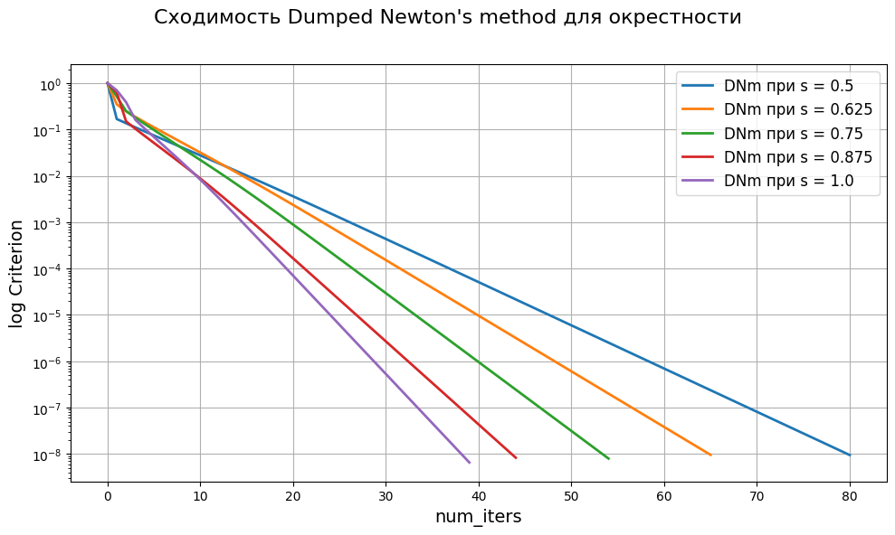

```python
plot_results(DNm_results, 'Cходимость Dumped Newton\'s method для окрестности')
```

```python
min_iters = min(DNm_results, key=lambda d: d['num_iters'][-1])['num_iters'][-1]

candidates = [
    d for d in DNm_results
    if abs(d['num_iters'][-1] - min_iters) < 2
]

best_final_newton_res = max(candidates, key=lambda d: d['Accuracy'][-1])
```